Packages and libraries are defined. This section is hidden (r1)

First I will read the data and write it to an SQL table

```r
Musk1 <- read.csv('C:/Users/emreg/Desktop/Master/IE582/Data/Musk1.csv', ,sep = ",",header=FALSE)
#creating an SQL connection named myConn
 myConn <- odbcConnect("IE582_HW1")
#
##writing the tables to database
sqlQuery(myConn,"IF EXISTS(SELECT *  FROM   Musk1)  DROP TABLE Musk1")
```

```
## character(0)
```

```r
sqlSave(myConn,Musk1,tablename="Musk1",rownames = F)
```

——————————-TASK 1A—————————————————- Firt I am going to apply PCA to undertand the data. Since first two columns corresponds Bag Class and Bag ID I am going to apply PCA from column 3 to 168.Normally we should scaling the data before applying PCA but “cor=TRUE” command of “R” makes this scaling automatically.

```r
#First two column corresponds bag class and bag ID
#Normally we should  scaling the data before applying PCA but "cor=TRUE" command makes this scaling automaticallay
pca<-princomp(Musk1[,3:168],cor = TRUE,scores = TRUE)
summary(pca)
```

```
## Importance of components:
##                           Comp.1    Comp.2     Comp.3     Comp.4
## Standard deviation     7.1952962 4.8073270 3.55611062 2.92188858
## Proportion of Variance 0.3118813 0.1392192 0.07618026 0.05143032
## Cumulative Proportion  0.3118813 0.4511005 0.52728074 0.57871106
##                            Comp.5     Comp.6     Comp.7     Comp.8
## Standard deviation     2.85773479 2.60187102 2.32140301 2.24739135
## Proportion of Variance 0.04919668 0.04078152 0.03246332 0.03042631
## Cumulative Proportion  0.62790774 0.66868926 0.70115258 0.73157890
##                            Comp.9   Comp.10    Comp.11    Comp.12
## Standard deviation     1.81831818 1.6883284 1.60356201 1.54166966
## Proportion of Variance 0.01991736 0.0171714 0.01549043 0.01431774
## Cumulative Proportion  0.75149625 0.7686677 0.78415808 0.79847583
##                           Comp.13    Comp.14    Comp.15     Comp.16
## Standard deviation     1.48576123 1.45214413 1.34646825 1.287366949
## Proportion of Variance 0.01329811 0.01270315 0.01092155 0.009983817
## Cumulative Proportion  0.81177394 0.82447709 0.83539863 0.845382449
##                            Comp.17    Comp.18     Comp.19     Comp.20
## Standard deviation     1.198867064 1.16425207 1.120779718 1.088686243
## Proportion of Variance 0.008658327 0.00816556 0.007567152 0.007139986
## Cumulative Proportion  0.854040776 0.86220634 0.869773487 0.876913474
##                            Comp.21     Comp.22     Comp.23     Comp.24
## Standard deviation     1.059036168 1.028281996 1.024267645 0.984423152
## Proportion of Variance 0.006756371 0.006369662 0.006320025 0.005837885
## Cumulative Proportion  0.883669845 0.890039506 0.896359532 0.902197417
##                            Comp.25     Comp.26     Comp.27    Comp.28
## Standard deviation     0.963374440 0.931918746 0.906238743 0.90125539
## Proportion of Variance 0.005590905 0.005231762 0.004947402 0.00489314
## Cumulative Proportion  0.907788323 0.913020085 0.917967486 0.92286063
##                            Comp.29   Comp.30     Comp.31     Comp.32
## Standard deviation     0.880448192 0.8575237 0.815660682 0.814106578
## Proportion of Variance 0.004669813 0.0044298 0.004007845 0.003992587
## Cumulative Proportion  0.927530440 0.9319602 0.935968086 0.939960673
##                            Comp.33     Comp.34     Comp.35     Comp.36
## Standard deviation     0.798884086 0.742943908 0.698012220 0.686432485
## Proportion of Variance 0.003844673 0.003325094 0.002935067 0.002838491
## Cumulative Proportion  0.943805347 0.947130441 0.950065508 0.952903999
##                            Comp.37     Comp.38     Comp.39     Comp.40
## Standard deviation     0.665185099 0.648668264 0.635554991 0.583645142
## Proportion of Variance 0.002665489 0.002534762 0.002433314 0.002052058
```

[output cut: 114 more lines]

```
## Standard deviation     2.770722e-02 2.744757e-02 2.486674e-02 2.425587e-02
## Proportion of Variance 4.624640e-06 4.538368e-06 3.725030e-06 3.544262e-06
## Cumulative Proportion  9.999685e-01 9.999730e-01 9.999767e-01 9.999803e-01
##                            Comp.157     Comp.158     Comp.159     Comp.160
## Standard deviation     2.340146e-02 2.283557e-02 2.090035e-02 1.933924e-02
## Proportion of Variance 3.298965e-06 3.141345e-06 2.631473e-06 2.253049e-06
## Cumulative Proportion  9.999836e-01 9.999867e-01 9.999894e-01 9.999916e-01
##                            Comp.161     Comp.162     Comp.163     Comp.164
## Standard deviation     1.786650e-02 1.723168e-02 1.670496e-02 1.411429e-02
## Proportion of Variance 1.922963e-06 1.788739e-06 1.681059e-06 1.200080e-06
## Cumulative Proportion  9.999935e-01 9.999953e-01 9.999970e-01 9.999982e-01
##                            Comp.165     Comp.166
## Standard deviation     1.332020e-02 1.100445e-02
## Proportion of Variance 1.068842e-06 7.295055e-07
## Cumulative Proportion  9.999993e-01 1.000000e+00
```

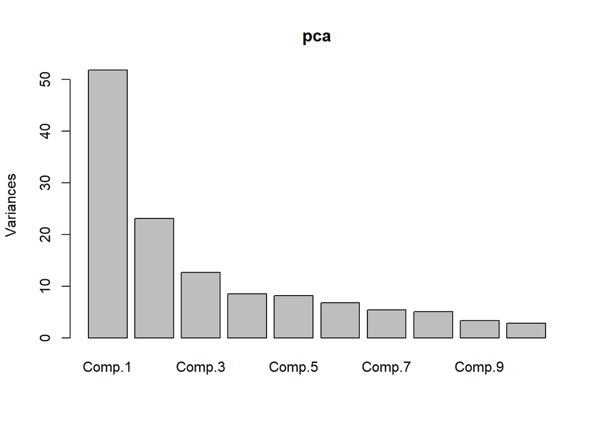

```r
plot(pca)
```

Here first, second and third components explains %31 , %13 and %8 of variation respectively. In total 52% is explained by the three components. Below I am going to go on my analysis based on pca results

PCA scores returns the estimation of Pca based on the eigenvalues. I am going to analyze first three components. Since first three explains only 52%, we may not obtain a clear picture

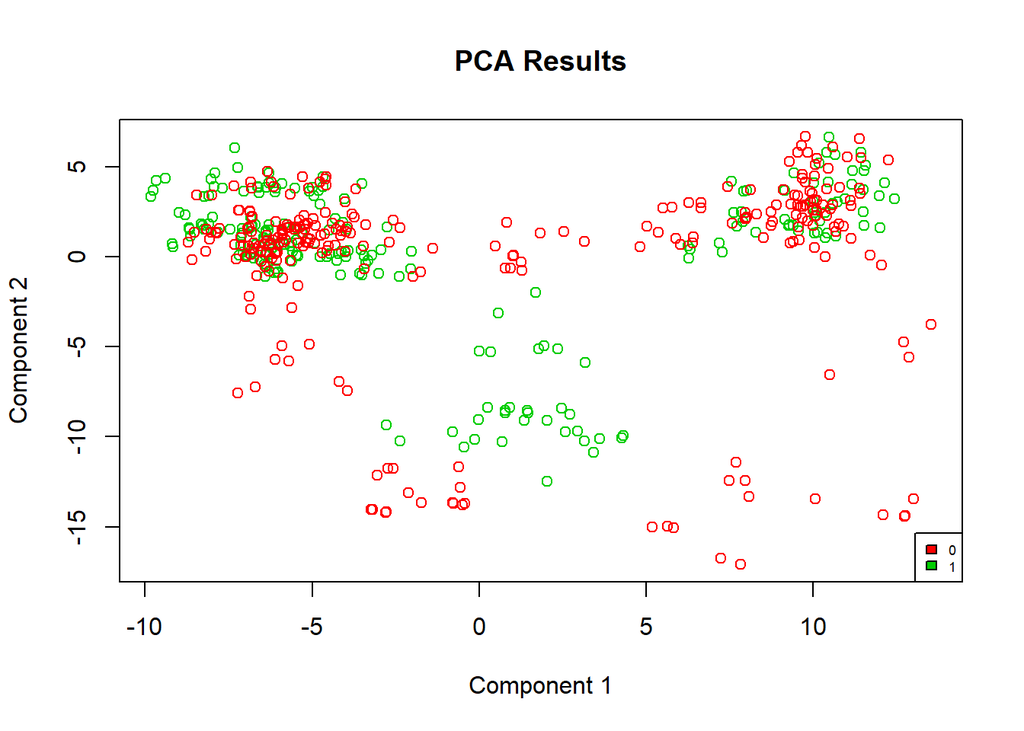

```r
#adding first two columns to pca&scores
pca_score_with_Instance <- cbind(Musk1$V1,Musk1$V2,pca$scores)
pca_score_with_Instance <- as.data.frame(pca_score_with_Instance)

plot(pca_score_with_Instance[,3:4],col = pca_score_with_Instance$V1+2,  xlab = "Component 1", ylab = "Component 2", main = "PCA Results")
legend("bottomright",cex = 0.55, legend = c("0", "1"),fill = 2:3)
```

The figure above shows PCA scores of two component. In middle part (Component 1 (0,5),Component 2(0,-10)) we mostly see Musks, In the bottom sides we observe Nonmasks but is not possible to generate a conclusion from this figure. Because most of the data is at top left and top right and they are mixed. At this point we cannot say that the assumption of the instance labels’ being as the same as bag labels is accurate. However first two component explains only 45% of variation. I am going to add component 3 to the figure.

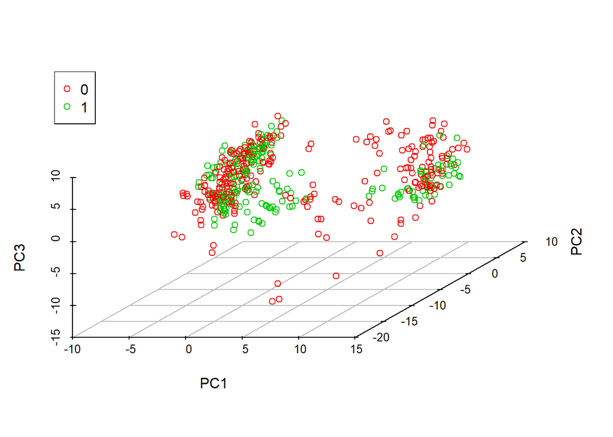

```r
#text(pca_score_with_Instance[,3],pca_score_with_Instance[,4],pca_score_with_Instance[1:50,2],cex = .75,pos=)
#text(mds[,1],mds[,2],names(distanceMat),cex = .75,pos=4)

scatterplot3d(pca_score_with_Instance[,3:5],color=(Musk1$V1+2),angle=45,grid=TRUE,box=FALSE,xlab="PC1", ylab="PC2",zlab="PC3")
legend("topleft",legend=c("0","1"),lty = 0,pch=1,col=c(2,3))
```

Again the clusters are mixed with 1 and 0 but this time still 48% variance is missing.

I also wanted to check pca results on Bag IDs.I will only display first 36 of the bags.

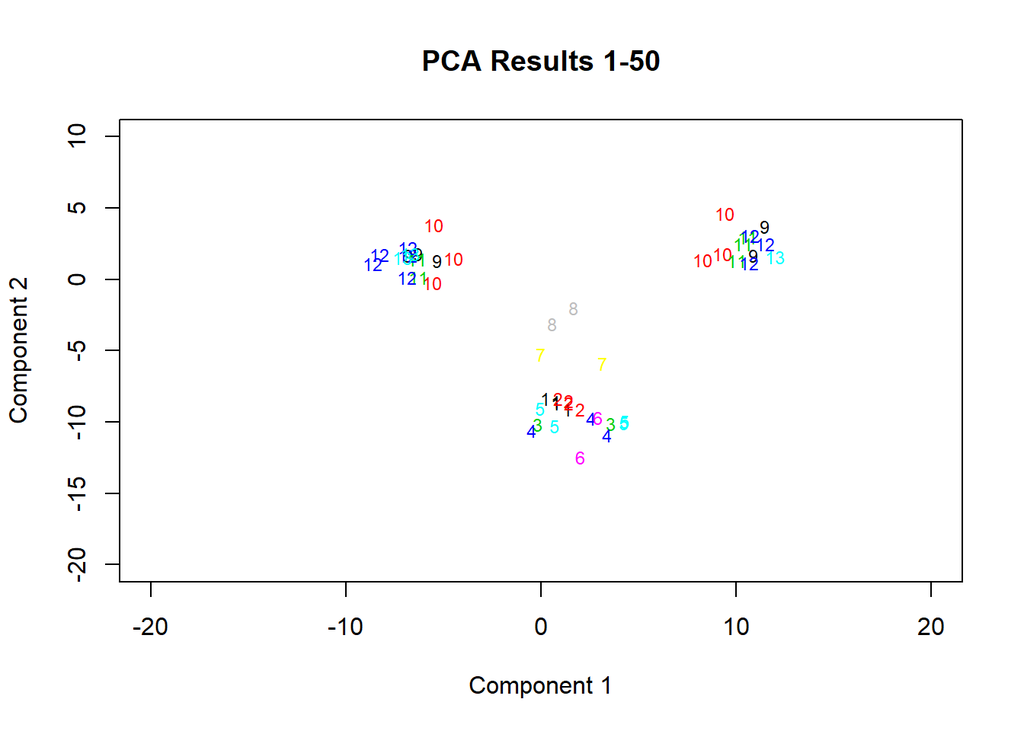

```r
plot( NULL, xlab = "Component 1", ylab = "Component 2", main = "PCA Results 1-50",xlim=c(-20,20) ,ylim=c(-20,10))
text(pca_score_with_Instance[1:50,3],pca_score_with_Instance[1:50,4],pca_score_with_Instance[1:50,2],cex = .75,col=pca_score_with_Instance[1:50,2])
```

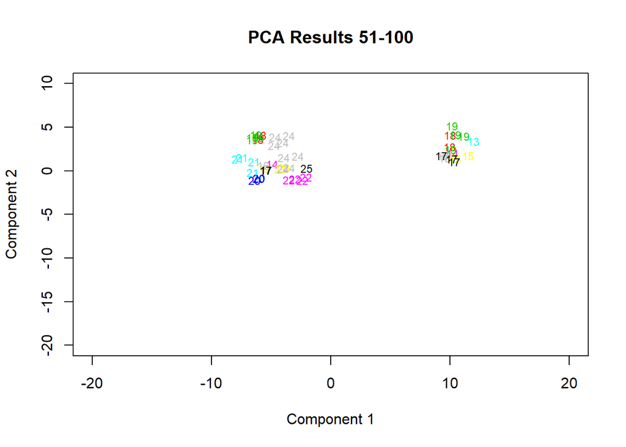

```r
plot( NULL, xlab = "Component 1", ylab = "Component 2", main = "PCA Results 51-100",xlim=c(-20,20) ,ylim=c(-20,10))
text(pca_score_with_Instance[51:100,3],pca_score_with_Instance[51:100,4],pca_score_with_Instance[51:100,2],cex = .75,col=pca_score_with_Instance[51:100,2])
```

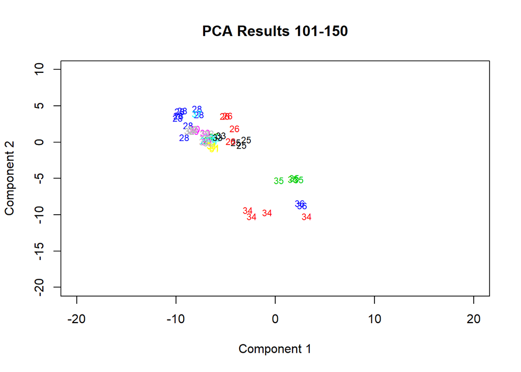

```r
plot( NULL, xlab = "Component 1", ylab = "Component 2", main = "PCA Results 101-150",xlim=c(-20,20) ,ylim=c(-20,10))
text(pca_score_with_Instance[101:150,3],pca_score_with_Instance[101:150,4],pca_score_with_Instance[101:150,2],cex = .75,col=pca_score_with_Instance[101:150,2])
```

[figure not shown]

```r
pca<-princomp(Musk1[,3:168],cor = TRUE,scores = TRUE) #scaling the data and applying PCA

par(mfrow=c(1,3))
plot(pca_score_with_Instance[pca_score_with_Instance$V1 == 1,3:4],col = Musk1$V2,  xlab = "Component 1", ylab = "Component 2", main = "PCA Results of Musks")
legend("bottomright",cex = 0.55, legend = c("0", "1"),
       fill = 2:3)
plot(pca_score_with_Instance[pca_score_with_Instance$V1 == 0,3:4],col = Musk1$V2,  xlab = "Component 1", ylab = "Component 2", main = "PCA Results of NonMusks")
legend("bottomright",cex = 0.55, legend = c("0", "1"),
       fill = 2:3)
plot(pca_score_with_Instance[,3:4],col = Musk1$V1+1,  xlab = "Component 1", ylab = "Component 2", main = "PCA Results of All")
legend("bottomright",cex = 0.55, legend = c("0", "1"),
       fill = 2:3)
```

Finally I draw musks graphs and nonmusk graphs with BagIDs. The graphs are similar and gives no clue about the assumption.

In the section below, I will apply MDS with euclidean and manhattan distances

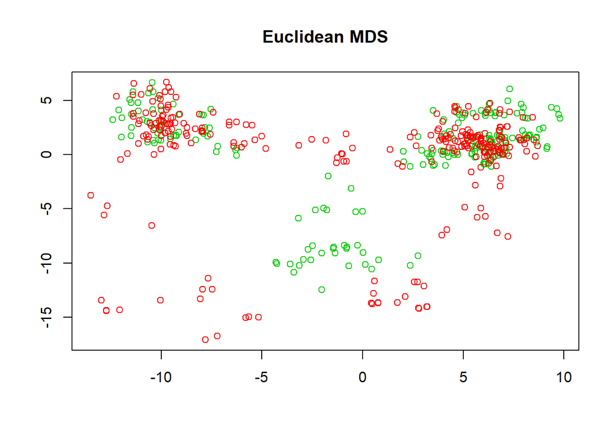

```r
Musk_MDS<-scale(Musk1[,3:168])
distanceMat<-dist(Musk_MDS, method = "euclidean")
mds=cmdscale(distanceMat) #applying MDS
plot(mds[,1],mds[,2],main='Euclidean MDS',xlab='', ylab='',col=Musk1$V1+2)
```

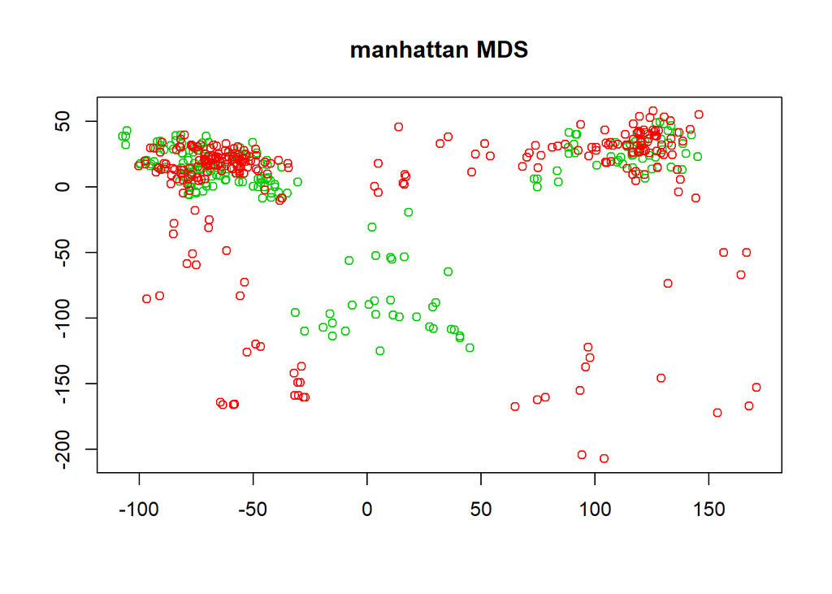

```r
Musk_MDS<-scale(Musk1[,3:168])
distanceMat<-dist(Musk_MDS, method = "manhattan")
mds=cmdscale(distanceMat) #applying MDS
plot(mds[,1],mds[,2],main='manhattan MDS',xlab='', ylab='',col=Musk1$V1+2)
```

The results are similar with PCA. I have same comments for the MDS.

————————TASK 1B)——————————————

In this part, In SQL querry I average the values having same BagID and assign the tabke to Musk_Avg.

```r
Musk_Avg <-sqlQuery(myConn,"SELECT [V1]
      ,[V2]
      ,AVG([V3]   )  AS V3
      ,AVG([V4]   )  AS V4
      ,AVG([V5]   )  AS V5
      ,AVG([V6]   )  AS V6
      ,AVG([V7]   )  AS V7
      ,AVG([V8]   )  AS V8
      ,AVG([V9]   )  AS V9
      ,AVG([V10]  )  AS V10
      ,AVG([V11]  )  AS V11
      ,AVG([V12]  )  AS V12
      ,AVG([V13]  )  AS V13
      ,AVG([V14]  )  AS V14
      ,AVG([V15]  )  AS V15
      ,AVG([V16]  )  AS V16
      ,AVG([V17]  )  AS V17
      ,AVG([V18]  )  AS V18
      ,AVG([V19]  )  AS V19
      ,AVG([V20]  )  AS V20
      ,AVG([V21]  )  AS V21
      ,AVG([V22]  )  AS V22
      ,AVG([V23]  )  AS V23
      ,AVG([V24]  )  AS V24
      ,AVG([V25]  )  AS V25
      ,AVG([V26]  )  AS V26
      ,AVG([V27]  )  AS V27
      ,AVG([V28]  )  AS V28
      ,AVG([V29]  )  AS V29
      ,AVG([V30]  )  AS V30
      ,AVG([V31]  )  AS V31
      ,AVG([V32]  )  AS V32
      ,AVG([V33]  )  AS V33
      ,AVG([V34]  )  AS V34
      ,AVG([V35]  )  AS V35
      ,AVG([V36]  )  AS V36
      ,AVG([V37]  )  AS V37
      ,AVG([V38]  )  AS V38
      ,AVG([V39]  )  AS V39
      ,AVG([V40]  )  AS V40
      ,AVG([V41]  )  AS V41
      ,AVG([V42]  )  AS V42
      ,AVG([V43]  )  AS V43
      ,AVG([V44]  )  AS V44
      ,AVG([V45]  )  AS V45
      ,AVG([V46]  )  AS V46
      ,AVG([V47]  )  AS V47
      ,AVG([V48]  )  AS V48
      ,AVG([V49]  )  AS V49
      ,AVG([V50]  )  AS V50
      ,AVG([V51]  )  AS V51
      ,AVG([V52]  )  AS V52
      ,AVG([V53]  )  AS V53
      ,AVG([V54]  )  AS V54
      ,AVG([V55]  )  AS V55
      ,AVG([V56]  )  AS V56
      ,AVG([V57]  )  AS V57
      ,AVG([V58]  )  AS V58
      ,AVG([V59]  )  AS V59
      ,AVG([V60]  )  AS V60
      ,AVG([V61]  )  AS V61
      ,AVG([V62]  )  AS V62
      ,AVG([V63]  )  AS V63
      ,AVG([V64]  )  AS V64
      ,AVG([V65]  )  AS V65
      ,AVG([V66]  )  AS V66
      ,AVG([V67]  )  AS V67
      ,AVG([V68]  )  AS V68
      ,AVG([V69]  )  AS V69
      ,AVG([V70]  )  AS V70
      ,AVG([V71]  )  AS V71
      ,AVG([V72]  )  AS V72
      ,AVG([V73]  )  AS V73
      ,AVG([V74]  )  AS V74
      ,AVG([V75]  )  AS V75
      ,AVG([V76]  )  AS V76
      ,AVG([V77]  )  AS V77
      ,AVG([V78]  )  AS V78
      ,AVG([V79]  )  AS V79
      ,AVG([V80]  )  AS V80
      ,AVG([V81]  )  AS V81
      ,AVG([V82]  )  AS V82
      ,AVG([V83]  )  AS V83
      ,AVG([V84]  )  AS V84
      ,AVG([V85]  )  AS V85
      ,AVG([V86]  )  AS V86
      ,AVG([V87]  )  AS V87
      ,AVG([V88]  )  AS V88
      ,AVG([V89]  )  AS V89
      ,AVG([V90]  )  AS V90
      ,AVG([V91]  )  AS V91
      ,AVG([V92]  )  AS V92
      ,AVG([V93]  )  AS V93
      ,AVG([V94]  )  AS V94
      ,AVG([V95]  )  AS V95
      ,AVG([V96]  )  AS V96
      ,AVG([V97]  )  AS V97
      ,AVG([V98]  )  AS V98
      ,AVG([V99]  )  AS V99
      ,AVG([V100] )  AS V100
      ,AVG([V101] )  AS V101
      ,AVG([V102] )  AS V102
      ,AVG([V103] )  AS V103
      ,AVG([V104] )  AS V104
      ,AVG([V105] )  AS V105
      ,AVG([V106] )  AS V106
      ,AVG([V107] )  AS V107
      ,AVG([V108] )  AS V108
      ,AVG([V109] )  AS V109
      ,AVG([V110] )  AS V110
      ,AVG([V111] )  AS V111
      ,AVG([V112] )  AS V112
      ,AVG([V113] )  AS V113
      ,AVG([V114] )  AS V114
      ,AVG([V115] )  AS V115
      ,AVG([V116] )  AS V116
      ,AVG([V117] )  AS V117
      ,AVG([V118] )  AS V118
      ,AVG([V119] )  AS V119
      ,AVG([V120] )  AS V120
      ,AVG([V121] )  AS V121
      ,AVG([V122] )  AS V122
      ,AVG([V123] )  AS V123
      ,AVG([V124] )  AS V124
      ,AVG([V125] )  AS V125
      ,AVG([V126] )  AS V126
      ,AVG([V127] )  AS V127
      ,AVG([V128] )  AS V128
      ,AVG([V129] )  AS V129
      ,AVG([V130] )  AS V130
      ,AVG([V131] )  AS V131
      ,AVG([V132] )  AS V132
      ,AVG([V133] )  AS V133
      ,AVG([V134] )  AS V134
      ,AVG([V135] )  AS V135
      ,AVG([V136] )  AS V136
      ,AVG([V137] )  AS V137
      ,AVG([V138] )  AS V138
      ,AVG([V139] )  AS V139
      ,AVG([V140] )  AS V140
      ,AVG([V141] )  AS V141
      ,AVG([V142] )  AS V142
      ,AVG([V143] )  AS V143
      ,AVG([V144] )  AS V144
      ,AVG([V145] )  AS V145
      ,AVG([V146] )  AS V146
      ,AVG([V147] )  AS V147
      ,AVG([V148] )  AS V148
      ,AVG([V149] )  AS V149
      ,AVG([V150] )  AS V150
      ,AVG([V151] )  AS V151
      ,AVG([V152] )  AS V152
      ,AVG([V153] )  AS V153
      ,AVG([V154] )  AS V154
      ,AVG([V155] )  AS V155
      ,AVG([V156] )  AS V156
      ,AVG([V157] )  AS V157
      ,AVG([V158] )  AS V158
      ,AVG([V159] )  AS V159
      ,AVG([V160] )  AS V160
      ,AVG([V161] )  AS V161
      ,AVG([V162] )  AS V162
      ,AVG([V163] )  AS V163
      ,AVG([V164] )  AS V164
      ,AVG([V165] )  AS V165
      ,AVG([V166] )  AS V166
      ,AVG([V167] )  AS V167
      ,AVG([V168] )  AS V168
  FROM [IE582_HW1].[dbo].[Musk1]
  GROUP BY V1,V2")
```

```r
#the pca analysis belows give error. Therefore I used prcomp command
#pca<-princomp(Musk_Avg[,3:94],cor = TRUE,scores = TRUE)

#I scaled the features
ScaledMusk <- scale(Musk_Avg[,3:168])

pca<-prcomp(Musk_Avg[,3:168]) #scaling the data and applying PCA
summary(pca)
```

```
## Importance of components:
##                             PC1      PC2      PC3     PC4       PC5
## Standard deviation     475.7539 387.2604 314.6223 267.002 208.40042
## Proportion of Variance   0.3238   0.2145   0.1416   0.102   0.06213
## Cumulative Proportion    0.3238   0.5384   0.6800   0.782   0.84410
##                              PC6       PC7       PC8      PC9     PC10
## Standard deviation     141.23799 132.65311 101.79277 97.18762 79.12478
## Proportion of Variance   0.02854   0.02517   0.01482  0.01351  0.00896
## Cumulative Proportion    0.87263   0.89781   0.91263  0.92615  0.93510
##                            PC11     PC12     PC13     PC14     PC15
## Standard deviation     78.22177 60.47769 56.56022 53.18525 51.38692
## Proportion of Variance  0.00875  0.00523  0.00458  0.00405  0.00378
## Cumulative Proportion   0.94386  0.94909  0.95367  0.95771  0.96149
##                            PC16     PC17     PC18     PC19     PC20
## Standard deviation     50.70480 45.64585 43.67060 41.60319 39.16767
## Proportion of Variance  0.00368  0.00298  0.00273  0.00248  0.00219
## Cumulative Proportion   0.96517  0.96815  0.97088  0.97335  0.97555
##                            PC21     PC22     PC23     PC24     PC25
## Standard deviation     37.73901 35.82651 35.15118 32.30291 30.96474
## Proportion of Variance  0.00204  0.00184  0.00177  0.00149  0.00137
## Cumulative Proportion   0.97759  0.97942  0.98119  0.98268  0.98405
##                            PC26     PC27     PC28     PC29     PC30
## Standard deviation     30.31166 28.60560 28.33754 27.50659 25.89492
## Proportion of Variance  0.00131  0.00117  0.00115  0.00108  0.00096
## Cumulative Proportion   0.98537  0.98654  0.98769  0.98877  0.98973
##                            PC31     PC32     PC33     PC34     PC35
## Standard deviation     23.74193 22.94134 22.27386 21.08024 19.93265
## Proportion of Variance  0.00081  0.00075  0.00071  0.00064  0.00057
## Cumulative Proportion   0.99054  0.99129  0.99200  0.99263  0.99320
##                            PC36     PC37     PC38     PC39     PC40
## Standard deviation     19.34587 18.95921 17.63789 17.41386 16.30781
## Proportion of Variance  0.00054  0.00051  0.00045  0.00043  0.00038
## Cumulative Proportion   0.99374  0.99425  0.99470  0.99513  0.99551
##                            PC41     PC42     PC43     PC44     PC45
## Standard deviation     16.20662 15.76482 15.35757 13.99018 13.45513
## Proportion of Variance  0.00038  0.00036  0.00034  0.00028  0.00026
## Cumulative Proportion   0.99589  0.99624  0.99658  0.99686  0.99712
##                            PC46     PC47    PC48     PC49     PC50
## Standard deviation     13.07260 12.68089 11.8067 11.47425 11.15935
## Proportion of Variance  0.00024  0.00023  0.0002  0.00019  0.00018
```

[output cut: 14 more lines]

```
## Standard deviation     4.55599 4.51509 4.31024 4.05326 3.77244 3.73047
## Proportion of Variance 0.00003 0.00003 0.00003 0.00002 0.00002 0.00002
## Cumulative Proportion  0.99975 0.99978 0.99981 0.99983 0.99985 0.99987
##                           PC75    PC76    PC77    PC78    PC79    PC80
## Standard deviation     3.39400 3.28481 3.06136 2.93760 2.67825 2.55536
## Proportion of Variance 0.00002 0.00002 0.00001 0.00001 0.00001 0.00001
## Cumulative Proportion  0.99989 0.99990 0.99992 0.99993 0.99994 0.99995
##                           PC81    PC82    PC83    PC84    PC85  PC86  PC87
## Standard deviation     2.44223 2.24033 2.12932 2.07369 1.92825 1.714 1.528
## Proportion of Variance 0.00001 0.00001 0.00001 0.00001 0.00001 0.000 0.000
## Cumulative Proportion  0.99996 0.99996 0.99997 0.99998 0.99998 1.000 1.000
##                         PC88  PC89  PC90  PC91      PC92
## Standard deviation     1.478 1.415 1.194 1.022 4.338e-14
## Proportion of Variance 0.000 0.000 0.000 0.000 0.000e+00
## Cumulative Proportion  1.000 1.000 1.000 1.000 1.000e+00
```

This time first three component explains %68 of variance.

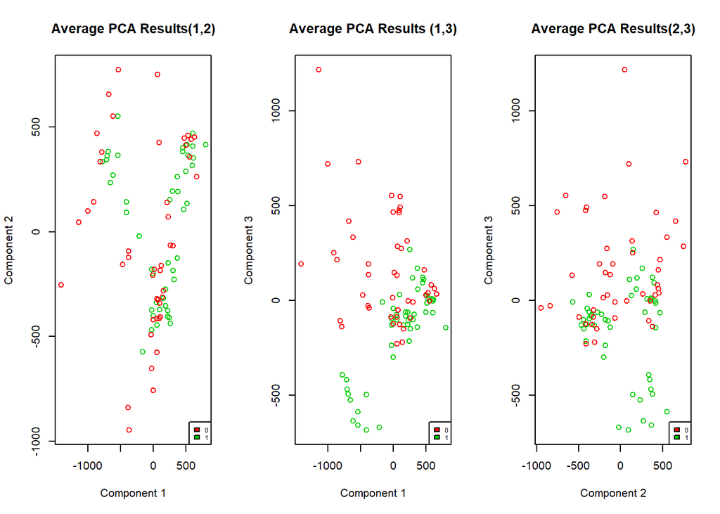

```r
par(mfrow=c(1,3))
plot(pca$x,col = Musk_Avg$V1+2,  xlab = "Component 1", ylab = "Component 2", main = "Average PCA Results(1,2)")
legend("bottomright",cex = 0.55, legend = c("0", "1"), fill = 2:3)


plot(cbind(pca$x[,1],pca$x[,3]),col = Musk_Avg$V1+2,  xlab = "Component 1", ylab = "Component 3", main = "Average PCA Results (1,3)")
legend("bottomright",cex = 0.55, legend = c("0", "1"), fill = 2:3)

plot(cbind(pca$x[,2],pca$x[,3]),col = Musk_Avg$V1+2,  xlab = "Component 2", ylab = "Component 3", main = "Average PCA Results(2,3)")
legend("bottomright",cex = 0.55, legend = c("0", "1"), fill = 2:3)
```

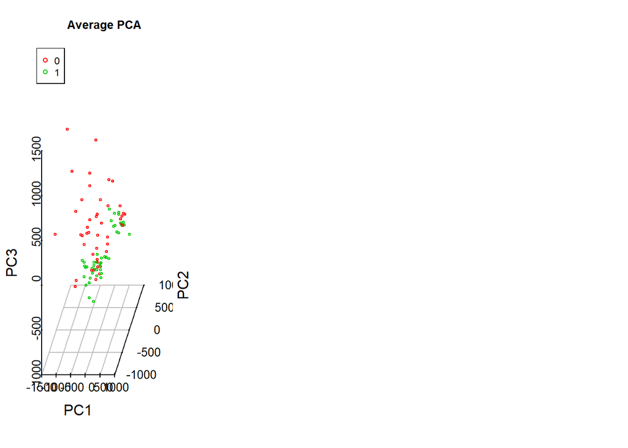

```r
scatterplot3d(pca$x[,1:3],color=(Musk_Avg$V1+2),angle=45,grid=TRUE,box=FALSE,xlab="PC1", ylab="PC2",zlab="PC3",main="Average PCA")
legend("topleft",legend=c("0","1"),lty = 0,pch=1,col=c(2,3))
```

The figures including component 3 gives information about Mask classification.At the top part there are zeros and at the bottom we observe greens.It looks good transformation for classiying bags. However still unexplained variance is 32% and many data point one and zeros are still close to each other in the center.

In this part I will apply MDS for average data

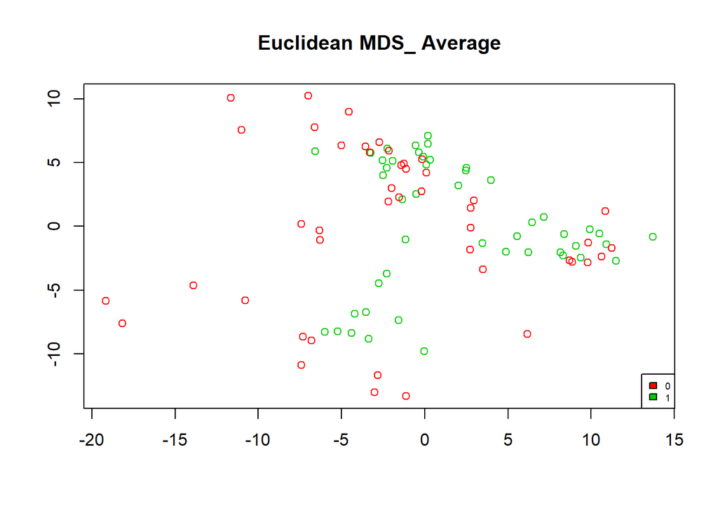

```r
Musk_MDS<-scale(Musk_Avg[,3:168])
distanceMat<-dist(Musk_MDS, method = "euclidean")
mds=cmdscale(distanceMat) #applying MDS
plot(mds[,1],mds[,2],main='Euclidean MDS_ Average',xlab='', ylab='',col=Musk_Avg$V1+2)
legend("bottomright",cex = 0.55, legend = c("0", "1"),  fill = 2:3)
```

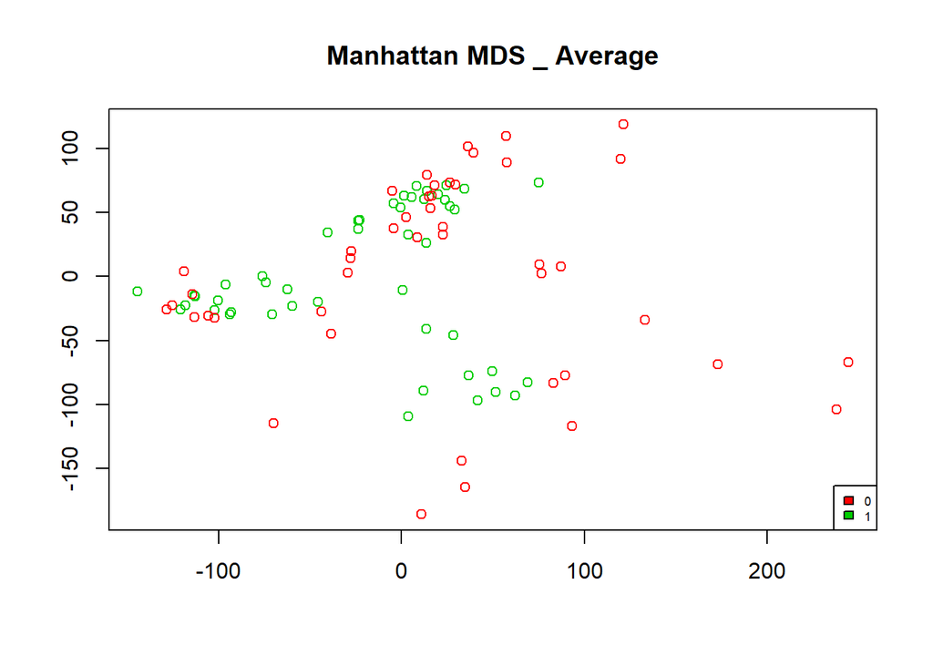

```r
Musk_MDS<-scale(Musk_Avg[,3:168])
distanceMat<-dist(Musk_MDS, method = "manhattan")
mds=cmdscale(distanceMat) #applying MDS
plot(mds[,1],mds[,2],main='Manhattan MDS _ Average',xlab='', ylab='',col=Musk_Avg$V1+2)
legend("bottomright",cex = 0.55, legend = c("0", "1"), fill = 2:3)
```

In MDS I cannot get extra information. Therefore this transformation is not as usuful as the transformation in PCA

———————— 1C BONUS ———————

I took geometric average using SQL SQRT(sum(Xi^2)). Since query is long, it is hidden I also tried median, mode, max , min but the geometric average gave better result so I will be showing it.

```r
Musk_Alt_Scaled<-scale(Musk_Avg_Alt[,3:168])



pca<-prcomp(Musk_Alt_Scaled) #scaling the data and applying PCA
summary(pca)
```

```
## Importance of components:
##                           PC1    PC2    PC3     PC4     PC5     PC6
## Standard deviation     6.1299 5.8623 4.4717 3.80794 2.59195 2.55916
## Proportion of Variance 0.2264 0.2070 0.1205 0.08735 0.04047 0.03945
## Cumulative Proportion  0.2264 0.4334 0.5538 0.64120 0.68167 0.72113
##                            PC7     PC8     PC9    PC10    PC11    PC12
## Standard deviation     2.36896 2.21542 1.91919 1.78834 1.78560 1.70785
## Proportion of Variance 0.03381 0.02957 0.02219 0.01927 0.01921 0.01757
## Cumulative Proportion  0.75493 0.78450 0.80669 0.82596 0.84516 0.86273
##                           PC13    PC14    PC15    PC16    PC17    PC18
## Standard deviation     1.43377 1.34955 1.33159 1.18177 1.11759 1.06678
## Proportion of Variance 0.01238 0.01097 0.01068 0.00841 0.00752 0.00686
## Cumulative Proportion  0.87512 0.88609 0.89677 0.90518 0.91271 0.91956
##                           PC19    PC20    PC21    PC22   PC23    PC24
## Standard deviation     1.05400 1.00429 0.96971 0.94363 0.8351 0.82388
## Proportion of Variance 0.00669 0.00608 0.00566 0.00536 0.0042 0.00409
## Cumulative Proportion  0.92626 0.93233 0.93800 0.94336 0.9476 0.95165
##                           PC25    PC26    PC27    PC28    PC29    PC30
## Standard deviation     0.79648 0.74457 0.73084 0.67279 0.65376 0.63811
## Proportion of Variance 0.00382 0.00334 0.00322 0.00273 0.00257 0.00245
## Cumulative Proportion  0.95547 0.95881 0.96203 0.96476 0.96733 0.96978
##                           PC31    PC32    PC33    PC34    PC35   PC36
## Standard deviation     0.59554 0.57983 0.57339 0.55571 0.51241 0.4827
## Proportion of Variance 0.00214 0.00203 0.00198 0.00186 0.00158 0.0014
## Cumulative Proportion  0.97192 0.97395 0.97593 0.97779 0.97937 0.9808
##                           PC37   PC38    PC39    PC40    PC41    PC42
## Standard deviation     0.46871 0.4638 0.45445 0.44323 0.42561 0.40997
## Proportion of Variance 0.00132 0.0013 0.00124 0.00118 0.00109 0.00101
## Cumulative Proportion  0.98209 0.9834 0.98463 0.98582 0.98691 0.98792
##                          PC43    PC44    PC45    PC46    PC47    PC48
## Standard deviation     0.4071 0.39160 0.37062 0.36324 0.35442 0.33367
## Proportion of Variance 0.0010 0.00092 0.00083 0.00079 0.00076 0.00067
## Cumulative Proportion  0.9889 0.98984 0.99067 0.99147 0.99222 0.99289
##                           PC49    PC50    PC51    PC52    PC53    PC54
## Standard deviation     0.32195 0.31695 0.30430 0.29654 0.26355 0.25587
## Proportion of Variance 0.00062 0.00061 0.00056 0.00053 0.00042 0.00039
## Cumulative Proportion  0.99352 0.99412 0.99468 0.99521 0.99563 0.99602
##                           PC55    PC56    PC57    PC58    PC59    PC60
## Standard deviation     0.24812 0.23614 0.22640 0.22038 0.21416 0.19710
## Proportion of Variance 0.00037 0.00034 0.00031 0.00029 0.00028 0.00023
```

[output cut: 10 more lines]

```
## Standard deviation     0.10721 0.09892 0.09175 0.08992 0.08668 0.08418
## Proportion of Variance 0.00007 0.00006 0.00005 0.00005 0.00005 0.00004
## Cumulative Proportion  0.99952 0.99958 0.99963 0.99968 0.99972 0.99977
##                           PC79    PC80    PC81    PC82    PC83    PC84
## Standard deviation     0.07636 0.07096 0.06632 0.06494 0.06241 0.05862
## Proportion of Variance 0.00004 0.00003 0.00003 0.00003 0.00002 0.00002
## Cumulative Proportion  0.99980 0.99983 0.99986 0.99988 0.99991 0.99993
##                           PC85    PC86    PC87    PC88    PC89    PC90
## Standard deviation     0.05466 0.05261 0.04188 0.03871 0.03709 0.03313
## Proportion of Variance 0.00002 0.00002 0.00001 0.00001 0.00001 0.00001
## Cumulative Proportion  0.99995 0.99996 0.99997 0.99998 0.99999 1.00000
##                           PC91      PC92
## Standard deviation     0.02432 4.425e-16
## Proportion of Variance 0.00000 0.000e+00
## Cumulative Proportion  1.00000 1.000e+00
```

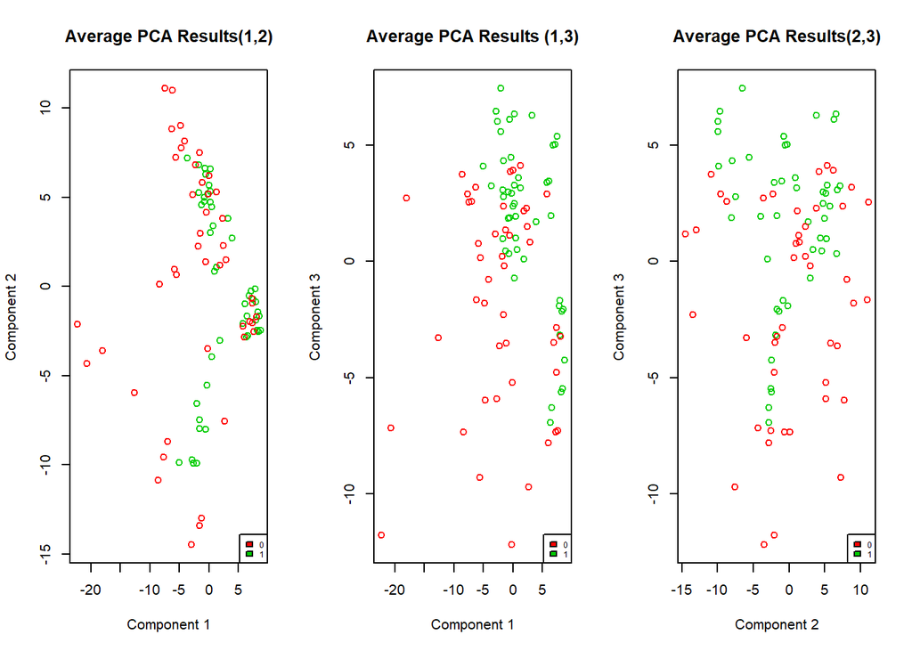

```r
par(mfrow=c(1,3))
plot(pca$x,col = Musk_Avg$V1+2,  xlab = "Component 1", ylab = "Component 2", main = "Average PCA Results(1,2)")
legend("bottomright",cex = 0.55, legend = c("0", "1"), fill = 2:3)


plot(cbind(pca$x[,1],pca$x[,3]),col = Musk_Avg$V1+2,  xlab = "Component 1", ylab = "Component 3", main = "Average PCA Results (1,3)")
legend("bottomright",cex = 0.55, legend = c("0", "1"), fill = 2:3)

plot(cbind(pca$x[,2],pca$x[,3]),col = Musk_Avg$V1+2,  xlab = "Component 2", ylab = "Component 3", main = "Average PCA Results(2,3)")
legend("bottomright",cex = 0.55, legend = c("0", "1"), fill = 2:3)
```

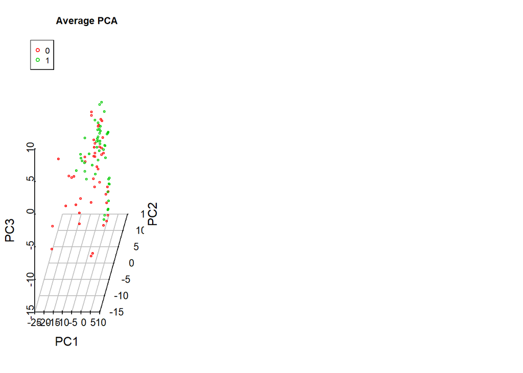

```r
scatterplot3d(pca$x[,1:3],color=(Musk_Avg$V1+2),angle=45,grid=TRUE,box=FALSE,xlab="PC1", ylab="PC2",zlab="PC3",main="Average PCA")
legend("topleft",legend=c("0","1"),lty = 0,pch=1,col=c(2,3))
```

Here first three component explains %55 of variance. Average PCA results 1-3 gives information.Left side of graphs are mostly zero and top right values are mostly 1.We can say that this transformation worked best to validate the assumption.

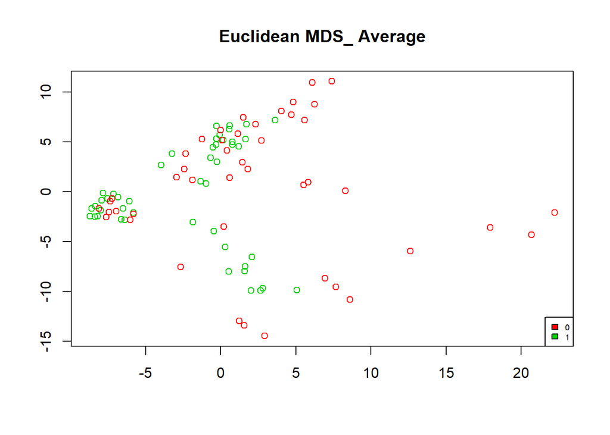

```r
distanceMat<-dist(Musk_Alt_Scaled, method = "euclidean")
mds=cmdscale(distanceMat) #applying MDS
plot(mds[,1],mds[,2],main='Euclidean MDS_ Average',xlab='', ylab='',col=Musk_Avg$V1+2)
legend("bottomright",cex = 0.55, legend = c("0", "1"),
       fill = 2:3)
```

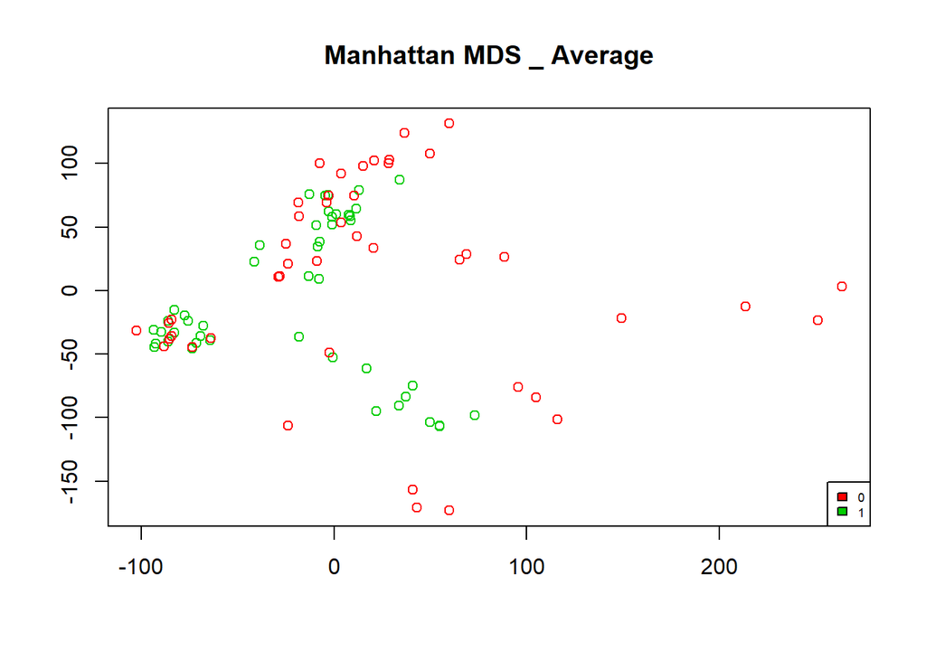

```r
distanceMat<-dist(Musk_Alt_Scaled, method = "manhattan")
mds=cmdscale(distanceMat) #applying MDS
plot(mds[,1],mds[,2],main='Manhattan MDS _ Average',xlab='', ylab='',col=Musk_Avg$V1+2)
legend("bottomright",cex = 0.55, legend = c("0", "1"),
       fill = 2:3)
```

The right part mostly includes zeros and left part includes green(1) points more. This provide better understanding compared to previous MDS

———————————–TASK 2.1———————————-

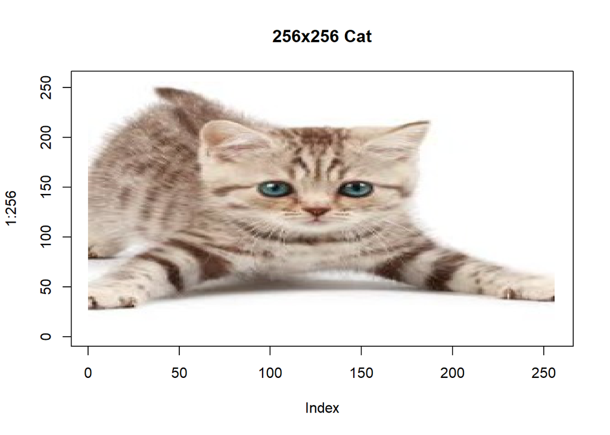

```r
#read cat images
cat_image<-readJPEG("C:/Users/emreg/Desktop/Master/IE582/Data/cat.jpg", native = F)

#display the image
plot(1:256, type='n',main="256x256 Cat")
rasterImage(cat_image,0,0,256,256,angle = 0,interpolate = F)
```

——————————-TASK 2.2—————————–

I will add noise between minpixel and maxpixel/10.

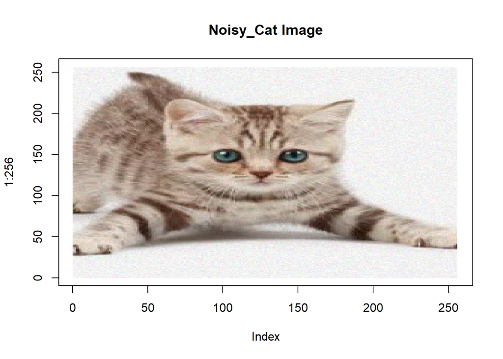

```r
#a)
# Adding Noise

minPixel = min(cat_image)
maxPixel_over_ten = max(cat_image)/10

Noisy_Cat<-array(0,dim = c(256,256,3))
for(i in 1:3){
for(k in 1:256){
for(l in 1:256){
  random_number<- 1 - runif(1, min = minPixel, max = maxPixel_over_ten)
 Noisy_Cat[k,l,i]<-cat_image[k,l,i]*random_number
}}}


#Display noisy cat image
plot(1:256 ,type='n',main = "Noisy_Cat Image")
rasterImage(Noisy_Cat,0,0,256,256,angle = 0,interpolate = F)
```

This 256x256x3 vectors. I will assign last two component zeros and will find blue, red and green images

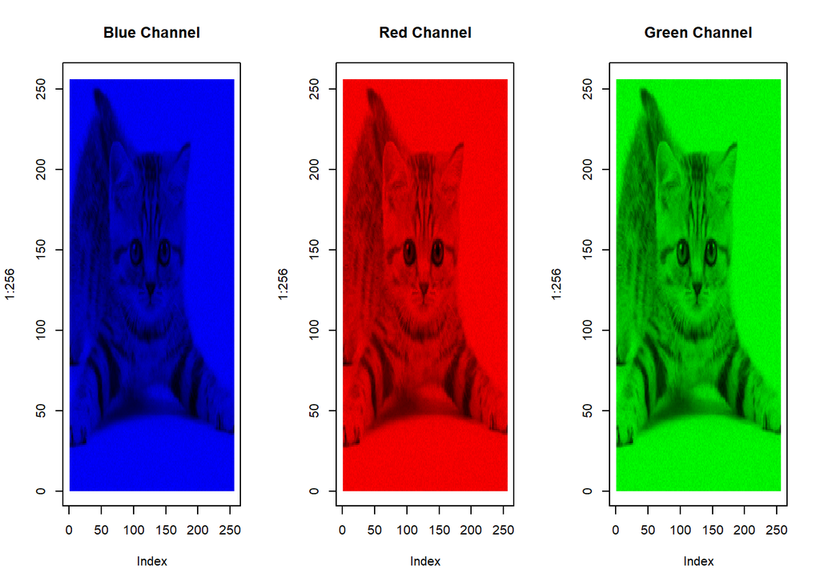

```r
#b)
#Creating blue channel images by assigning others to zero
Noisy_Cat_b<-Noisy_Cat
Noisy_Cat_b[,,1]=0
Noisy_Cat_b[,,2]=0
#Creating red channel images by assigning others to zero
Noisy_Cat_r<-Noisy_Cat
Noisy_Cat_r[,,2]=0
Noisy_Cat_r[,,3]=0
#Creating green channel images by assigning others to zero
Noisy_Cat_g<-Noisy_Cat
Noisy_Cat_g[,,1]=0
Noisy_Cat_g[,,3]=0

#Display the channels
par(mfrow=c(1,3))
plot(1:256 ,type='n',main = "Blue Channel")
rasterImage(Noisy_Cat_b,0,0,256,256,angle = 0,interpolate = F)
plot(1:256 ,type='n',main = "Red Channel")
rasterImage(Noisy_Cat_r,0,0,256,256,angle = 0,interpolate = F)
plot(1:256 ,type='n',main = "Green Channel")
rasterImage(Noisy_Cat_g,0,0,256,256,angle = 0,interpolate = F)
```

———TASK 2.3 ——————————–

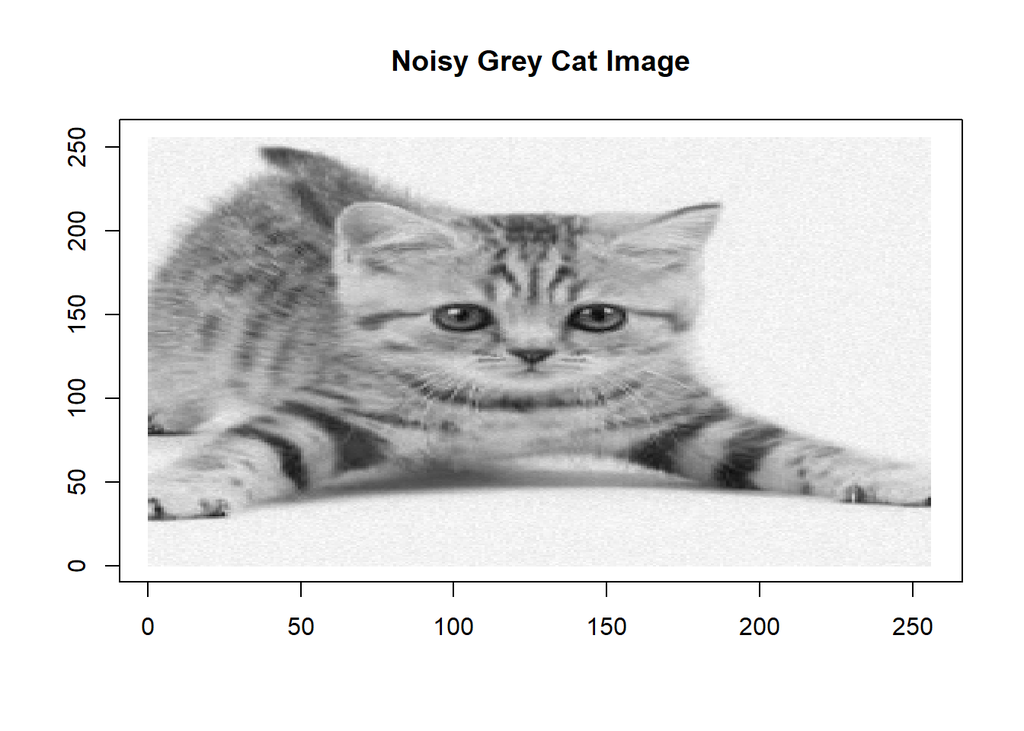

```r
#converts noisy image to grey
noisy_grey_cat <- Noisy_Cat[,,1] + Noisy_Cat[,,2] + Noisy_Cat[,,3]
noisy_grey_cat <- noisy_grey_cat/max(noisy_grey_cat)

#Display The Noisy Grey Cat Image
plot(1:256,main = "Noisy Grey Cat Image", xlab = "", ylab = "", axes = T, col = 0)
rasterImage(noisy_grey_cat,0,0,256,256,angle = 0,interpolate = F)
```

————–TASK 2.3.A ———————–

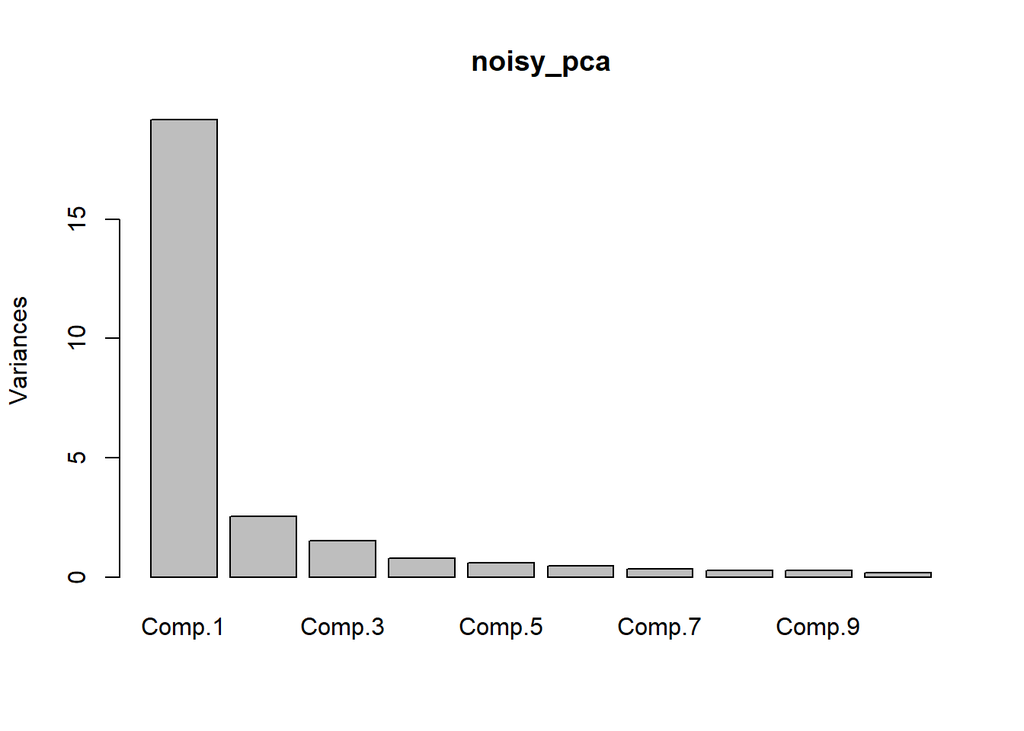

```r
############### 25x25

sample_vector <- rep(NA,625)
imgdata <- rep(list(sample_vector), 232*232)

#image data keeps 232x232 vectors of 625 data
k <- 1
for (i in 1:232) {
  for (j in 1:232) {
    imgdata[[k]] <- as.vector(noisy_grey_cat[(i):(i+24),(j):(j+24)])
    k <- k+1
  }
}

#now in image data there are 232x232 instances and 625 features
imgdata <- as.data.table(matrix(unlist(imgdata), ncol = 625, byrow = TRUE))

#applying principal component analysis
noisy_pca <- princomp(imgdata)
plot(noisy_pca)
```

```r
summary(noisy_pca)
```

```
## Importance of components:
##                           Comp.1    Comp.2    Comp.3    Comp.4     Comp.5
## Standard deviation     4.3784482 1.5949815 1.2318220 0.8901801 0.77339902
## Proportion of Variance 0.6732955 0.0893463 0.0532919 0.0278305 0.02100741
## Cumulative Proportion  0.6732955 0.7626418 0.8159337 0.8437642 0.86477163
##                            Comp.6     Comp.7     Comp.8    Comp.9
## Standard deviation     0.67810861 0.58984353 0.53965300 0.5152285
## Proportion of Variance 0.01614968 0.01221909 0.01022809 0.0093232
## Cumulative Proportion  0.88092131 0.89314040 0.90336849 0.9126917
##                            Comp.10     Comp.11     Comp.12     Comp.13
## Standard deviation     0.431656654 0.381650133 0.360669694 0.345072806
## Proportion of Variance 0.006543983 0.005115595 0.004568615 0.004182026
## Cumulative Proportion  0.919235670 0.924351265 0.928919880 0.933101906
##                            Comp.14     Comp.15     Comp.16     Comp.17
## Standard deviation     0.321295648 0.296974151 0.292645694 0.266137598
## Proportion of Variance 0.003625559 0.003097438 0.003007804 0.002487584
## Cumulative Proportion  0.936727465 0.939824903 0.942832707 0.945320291
##                           Comp.18     Comp.19     Comp.20    Comp.21
## Standard deviation     0.24855484 0.247623343 0.234090571 0.22725993
## Proportion of Variance 0.00216975 0.002153518 0.001924567 0.00181389
## Cumulative Proportion  0.94749004 0.949643559 0.951568126 0.95338202
##                            Comp.22     Comp.23    Comp.24     Comp.25
## Standard deviation     0.207082985 0.206005624 0.20449346 0.191783162
## Proportion of Variance 0.001506101 0.001490471 0.00146867 0.001291773
## Cumulative Proportion  0.954888118 0.956378588 0.95784726 0.959139031
##                            Comp.26    Comp.27     Comp.28     Comp.29
## Standard deviation     0.188022807 0.18064457 0.179253804 0.175158953
## Proportion of Variance 0.001241613 0.00114608 0.001128501 0.001077531
## Cumulative Proportion  0.960380645 0.96152673 0.962655226 0.963732758
##                            Comp.30      Comp.31      Comp.32      Comp.33
## Standard deviation     0.172093777 0.1672329610 0.1640183762 0.1627769857
## Proportion of Variance 0.001040149 0.0009822206 0.0009448227 0.0009305748
## Cumulative Proportion  0.964772907 0.9657551275 0.9666999502 0.9676305250
##                             Comp.34      Comp.35      Comp.36      Comp.37
## Standard deviation     0.1588554654 0.1556481861 0.1505591487 0.1500105590
## Proportion of Variance 0.0008862773 0.0008508508 0.0007961219 0.0007903309
## Cumulative Proportion  0.9685168023 0.9693676531 0.9701637750 0.9709541059
##                             Comp.38      Comp.39      Comp.40      Comp.41
## Standard deviation     0.1439849276 0.1403234639 0.1382363772 0.1314625070
## Proportion of Variance 0.0007281139 0.0006915537 0.0006711351 0.0006069726
```

[output cut: 570 more lines]

```
## Standard deviation     1.405638e-02 1.403063e-02 1.393254e-02 1.389035e-02
## Proportion of Variance 6.939242e-06 6.913847e-06 6.817510e-06 6.776288e-06
## Cumulative Proportion  9.999003e-01 9.999072e-01 9.999140e-01 9.999208e-01
##                            Comp.614     Comp.615     Comp.616     Comp.617
## Standard deviation     1.386970e-02 1.385005e-02 1.380908e-02 1.378966e-02
## Proportion of Variance 6.756156e-06 6.737021e-06 6.697228e-06 6.678399e-06
## Cumulative Proportion  9.999276e-01 9.999343e-01 9.999410e-01 9.999477e-01
##                            Comp.618     Comp.619     Comp.620     Comp.621
## Standard deviation     1.377477e-02 1.374449e-02 1.369848e-02 1.366306e-02
## Proportion of Variance 6.663988e-06 6.634720e-06 6.590376e-06 6.556337e-06
## Cumulative Proportion  9.999543e-01 9.999610e-01 9.999676e-01 9.999741e-01
##                            Comp.622     Comp.623     Comp.624     Comp.625
## Standard deviation     1.364607e-02 1.363282e-02 1.357314e-02 1.344139e-02
## Proportion of Variance 6.540042e-06 6.527348e-06 6.470326e-06 6.345320e-06
## Cumulative Proportion  9.999807e-01 9.999872e-01 9.999937e-01 1.000000e+00
```

First component consitutes %67 of total variance and first three components explains %82 total variances. In order to reconstruct the images I am going to use pca score parameters.pca$scores[,1] shows the score calculated based on the first pca component. However to use the scores, we have to scale it before. Otherwise I could get values out of [0,1]  
————–TASK 2.3.B ———————–

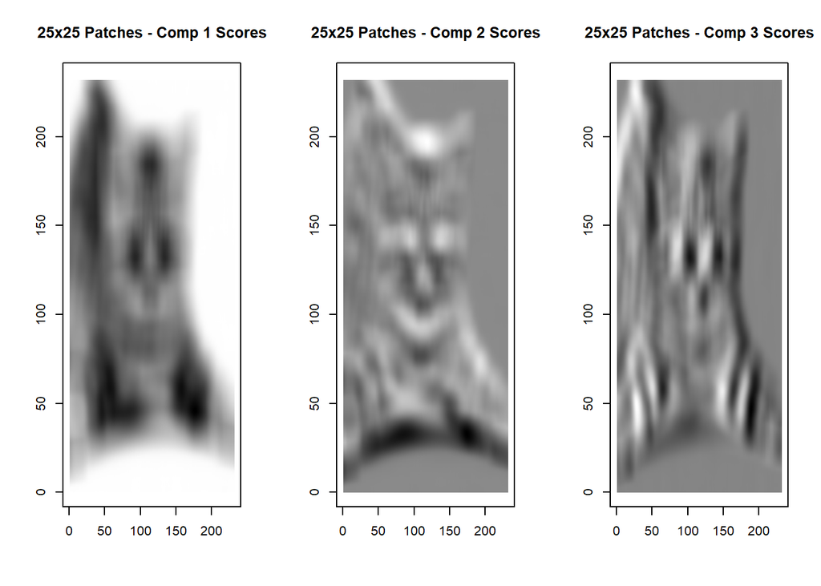

```r
#score vector is 232x1 vector. After scaling it I am forming the Component_1 matrix
par(mfrow=c(1,3))
Component_1 <- (noisy_pca$scores[,1] - min(noisy_pca$scores[,1]))/(max(noisy_pca$scores[,1])-min(noisy_pca$scores[,1]))
plot(1:232,1:232, ann = TRUE,col=0, main = "25x25 Patches - Comp 1 Scores", xlab = "", ylab = "")
rasterImage(matrix(Component_1, 232, byrow=TRUE),0,0,232,232)

Component_2 <- (noisy_pca$scores[,2] - min(noisy_pca$scores[,2]))/(max(noisy_pca$scores[,2])-min(noisy_pca$scores[,2]))
plot(1:232,1:232, ann = TRUE,col=0, main = "25x25 Patches - Comp 2 Scores", xlab = "", ylab = "")
rasterImage(matrix(Component_2, 232, byrow=TRUE),0,0,232,232)

Component_3 <- (noisy_pca$scores[,3] - min(noisy_pca$scores[,3]))/(max(noisy_pca$scores[,3])-min(noisy_pca$scores[,3]))
plot(1:232,1:232, ann = TRUE,col=0, main = "25x25 Patches - Comp 3 Scores", xlab = "", ylab = "")
rasterImage(matrix(Component_3, 232, byrow=TRUE),0,0,232,232)
```

Since first component explains the highest variance, it is the best represenatation.

————–TASK 2.3.C ———————– Pca$loading parameters gives the corresponding eigen values. In order to plot them,we have to scale them before between [0,1]

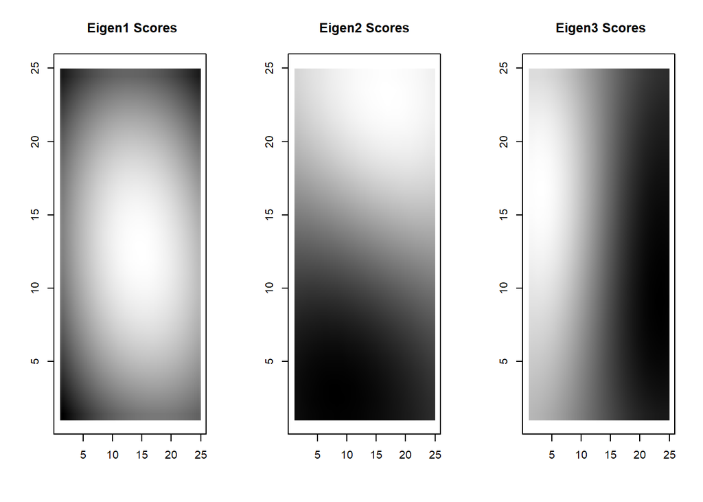

```r
#scaling process for the first three component. There 25 components in total.
eigen1 <- matrix((noisy_pca$loadings[,1 ]-min(noisy_pca$loadings[,1 ]))/(max(noisy_pca$loadings[,1 ])-min(noisy_pca$loadings[,1 ])),25,byrow=TRUE)
eigen2 <- matrix((noisy_pca$loadings[,2 ]-min(noisy_pca$loadings[,2 ]))/(max(noisy_pca$loadings[,2 ])-min(noisy_pca$loadings[,2 ])),25,byrow=TRUE)
eigen3 <- matrix((noisy_pca$loadings[,3 ]-min(noisy_pca$loadings[,3 ]))/(max(noisy_pca$loadings[,3 ])-min(noisy_pca$loadings[,3 ])),25,byrow=TRUE)


#displaying eigen
par(mfrow=c(1,3))
plot(1:25,1:25, ann = TRUE,col=0, main = " Eigen1 Scores", xlab = "", ylab = "")
rasterImage(matrix(eigen1, 25, byrow=TRUE),1,1,25,25)
plot(1:25,1:25, ann = TRUE,col=0, main = "Eigen2 Scores", xlab = "", ylab = "")
rasterImage(matrix(eigen2, 25, byrow=TRUE),1,1,25,25)
plot(1:25,1:25, ann = TRUE,col=0, main = " Eigen3 Scores", xlab = "", ylab = "")
rasterImage(matrix(eigen3, 25, byrow=TRUE),1,1,25,25)
```

I also added the Eigen24 and Eigen25 to bottom part. Values vary more compared to chart above.

"Loadings are interpreted as the coefficients of the linear combination of the initial variables from which the principal components are constructed.From a numerical point of view, the loadings are equal to the coordinates of the variables divided by the square root of the eigenvalue associated with the component(Source:Husson et al., Exploratory Multivariate Analysis by Examples Using R, 2011)

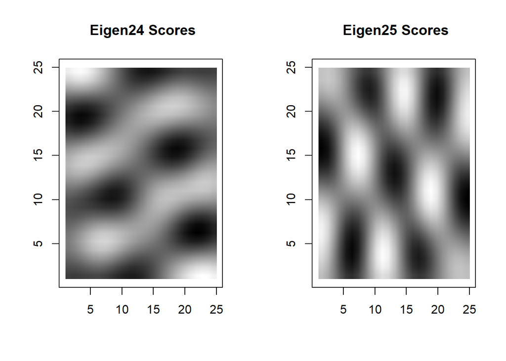

```r
par(mfrow=c(1,2))
eigen24 <- matrix((noisy_pca$loadings[,24 ]-min(noisy_pca$loadings[,24 ]))/(max(noisy_pca$loadings[,24 ])-min(noisy_pca$loadings[,24 ])),25,byrow=TRUE)
plot(1:25,1:25, ann = TRUE,col=0, main = " Eigen24 Scores", xlab = "", ylab = "")
rasterImage(matrix(eigen24, 25, byrow=TRUE),1,1,25,25)

eigen25 <- matrix((noisy_pca$loadings[,25 ]-min(noisy_pca$loadings[,25 ]))/(max(noisy_pca$loadings[,25 ])-min(noisy_pca$loadings[,25 ])),25,byrow=TRUE)
plot(1:25,1:25, ann = TRUE,col=0, main = " Eigen25 Scores", xlab = "", ylab = "")
rasterImage(matrix(eigen25, 25, byrow=TRUE),1,1,25,25)
```